# Clustering on Project Completion Reports

Arthur Charpentier and Ewen Gallic

2020-10-03

# 1 Data Cleaning

## 1.1 Loading Data

Two types of project completion reports are considered:

- the reports made by the beneficiaries of the allowances (project completion reports, or PCR)
- reports produced internally by IFAD (project completion reports validation, or PCRV)

For the PCR, the following information is available:

- the report in PDF format
- the extraction of the text content (for old or digitally copied reports, a character recognition has been previously performed outside this work)
- metadata.

For the PCRV, only the metadata is available.

### 1.1.1 Project Completion Reports (PCRs)

*Note*: the R codes of this subsection are also available in the file `01_extract_text.R`.

#### 1.1.1.1 Evaluation Ratings

Funded projects are evaluated against multiple criteria. The values taken by these criteria are available in an Excel file that can be loaded into R :

```r
library(tidyverse)
library(readxl)
df_completion_ratings <- read_excel("../data/completion_ratings-2020-07-18.xlsx")
head(df_completion_ratings)
```

```
## # A tibble: 6 x 53
##   Region Country `Project Id` Name  `Short Name` `Current Projec…
##   <chr>  <chr>          <dbl> <chr> <chr>        <chr>
## 1 APR    Sri La…   1100000001 Kiri… Kirindi Oya… Financial Closu…
## 2 APR    Thaila…   1100000005 Seco… Second Nort… Financial Closu…
## 3 APR    Philip…   1100000008 Maga… Magat River… Financial Closu…
## 4 APR    Bangla…   1100000009 Pabn… Pabna Irrig… Financial Closu…
## 5 APR    Nepal     1100000010 Inte… Sagarmatha … Financial Closu…
## 6 APR    Pakist…   1100000018 Smal… Credit Proj… Financial Closu…
## # … with 47 more variables: `Cooperating Institution` <chr>, `Concept
## #   Approval` <dttm>, `QE/DR Cleared` <dttm>, `QA/DR Endorsed` <dttm>, `EB
## #   Approval` <dttm>, `Entry Into Force` <dttm>, `Available for
## #   Disbursement` <dttm>, `First Disbursement` <dttm>, `MTR Date` <dttm>,
## #   `Original Completion` <dttm>, `Current Completion` <dttm>, `Financial
## #   Closure` <dttm>, `Completion report approval date` <dttm>, `Effectiveness
## #   Lag (months)` <dbl>, `Last Audit Receipt` <dttm>, `Number of SIS
## #   Missions` <dbl>, `Environmental and Social Category` <chr>, `Climate Risk
## #   Classification` <dbl>, `PAR Value` <chr>, `Total Project Financing` <dbl>,
## #   `IFAD Total Financing` <dbl>, `ASAP Grant` <dbl>, `Domestic
## #   Cofinancing` <dbl>, `International Cofinancing` <dbl>, `Project
## #   performance` <lgl>, `1. Relevance` <dbl>, `2. Effectiveness` <dbl>, `3.
## #   Efficiency` <dbl>, `4. Sustainability` <dbl>, `Rural poverty impact` <dbl>,
## #   `1. Households’ incomes and assets` <dbl>, `2. Human and social
## #   capital` <dbl>, `3. Food security` <dbl>, `4. Agricultural
## #   productivity` <dbl>, `5. Institutions and policies` <dbl>, `Additional
## #   evaluation criteria` <lgl>, `1. Gender equality and women's
## #   empowerment` <dbl>, `2. Innovation` <dbl>, `3. Scaling up` <dbl>, `4.
## #   Environment and natural resource management` <dbl>, `5. Adaptation to
## #   climate change` <dbl>, `6. Targeting and outreach` <dbl>, `7. Access to
## #   markets` <dbl>, `Partners performance` <lgl>, `1. Ifad's
## #   performance` <dbl>, `2. Government performance` <dbl>, `Overall project
## #   achievement` <dbl>
```

#### 1.1.1.2 Extraction of Text

Each project involves the completion of multiple reports:

- `PDR`: design report
- `MTR`: mid-term report
- `PSR`: supervision report
- `PCR`: project completions report

Our focus here is on PCRs. The corpus of all reports have already been extracted from the PDF reports. They have been saved in a CSV file. Each row of the dataset gives the text extracted from a single page of a report. The columns of the dataset are as follows:

| Name | Type | Description |
| --- | --- | --- |
| `Country` | `character` | the country where the project was funded |
| `ID` | `character` | the unique identifier of the report |
| `Type of report` | `character` | the type of report (PDR, MTR, PCR, PSR, see below for details) |
| `Page` | `double` | page number |
| `File_name` | `character` | name of the PDF report |
| `text` | `character` | extracted text |

The data can be loaded into the R session using the code below:

```r
reports <-
  read_delim("03_Cornell_input_Phase01.csv",
             col_types =
               cols(
                 Country = col_character(),
                 ID = col_character(),
                 `Type of report` = col_character(),
                 Page = col_double(),
                 File_name = col_character(),
                 text = col_character()
               ),
             delim = ";")
```

We focus on the PCRs:

```r
completion_reports <-
  reports %>%
  filter(`Type of report` == "PCR")
```

The number of available pages per report can be obtained easily:

```r
completion_reports %>%
  group_by(ID) %>%
  count()
```

```
## # A tibble: 493 x 2
## # Groups:   ID [493]
##    ID             n
##    <chr>      <int>
##  1 1100000082    52
##  2 1100000135    88
##  3 1100000136    22
##  4 1100000166    52
##  5 1100000232    95
##  6 1100000234    59
##  7 1100000235   219
##  8 1100000237    50
##  9 1100000240    61
## 10 1100000241   106
## # … with 483 more rows
```

Completion reports contain a section on lessons learned during the project. The content of this section is subject to statistical analysis. It is therefore important to extract the text of this section properly. Unfortunately, the diversity of documents, the lack of compliance with standards and the presence of some documents in image rather than text format make this task difficult to be automated. As a first step, we wanted to automatically extract the section typically titled “Lessons Learned” from the texts. This task proved impossible for several reasons that we detail here.

Our initial approach was simple: locate the beginning of the “Lessons Learned” section, then locate the end of the section. This last task is not straightforward: sometimes it is the final section, but sometimes it is followed by a “Conclusion” section. Most of the time, it is followed by an appendix, which is not easy to recognize. An attempt has been made to locate the numbering of the sections, but again, the diversity in the documents complicates the task (Roman numerals, Arabic numerals, letters); besides, the problem regarding the presence or absence of a subsequent section occurs again.

The capacity of the algorithm developed to perform the extraction being far from satisfactory (at most, about fifty documents processed), we opted for a more tedious but safer method: the manual retrieval of the paragraphs to be imported. For each document, we write down in a table the page in which the “Lessons Learned” section begins and the page in which it ends. We also add the beginning of the first paragraph of that section and the last words.

The following code prepares the empty table that needs to be manually filled:

```r
completion_reports %>%
  filter(ID %in% df_completion_ratings$`Project Id`) %>%
  group_by(ID) %>%
  slice(1) %>%
  select(ID, File_name) %>%
  mutate(tmp = str_c('"', ID, '", "', File_name, '", "", "", "","",\n')) %>%
  .$tmp %>%
  cat()
```

Each row of this table should contain:

- the report identifier
- the name of one of the pages (used to find your way around when searching for files manually, then unused)
- the start page of the “Lessons Learned” section identified manually
- the end page of the “Lessons Learned” section identified manually
- the first words of the section
- the last words of the section

For a better understanding, here is an illustrative example for the report whose identifier is `1100001662`. This report concerns a project in Vietnam. The PDF file is named `vietnam_1100001662_completion-report.pdf`. We see that the “Lessons Learned” section runs from page 53 to 54. The first sentence of the section starts with the following string: `The SRDP implementation has actually been`. It ends with: `CSA and PPP investments`. Thus, the table we create will contain the following row:

```r
c("1100001662", "vietnam_1100001662_completion-report.pdf.content1",
  "53", "54", "The SRDP implementation has actually been","CSA and PPP investments")
```

This vector is then transformed into a table:

```r
table_infos_example <-
  c("1100001662", "vietnam_1100001662_completion-report.pdf.content1",
  "53", "54", "The SRDP implementation has actually been","CSA and PPP investments") %>%
  matrix(ncol = 6, byrow = TRUE) %>%
  as_tibble() %>%
  magrittr::set_colnames(c("ID", "File_name", "start_page", "end_page", "start_text", "end_text"))
print(table_infos_example)
```

```
## # A tibble: 1 x 6
##   ID      File_name            start_page end_page start_text        end_text
##   <chr>   <chr>                <chr>      <chr>    <chr>             <chr>
## 1 110000… vietnam_1100001662_… 53         54       The SRDP impleme… CSA and PP…
```

Next, we use a function that fetches from pages 53 to 54 the part of the text that starts with `The SRDP implementation has actually been` and ends with `CSA and PPP investments`.

```r
#' extract_lessons_learned
#' Extracts the "Lessons Learned" part from document whose information is contained in row `i` from `table_infos`
#' @param i (integer) the ith row of `table_infos`
#' @param table_infos table that contains the ID of the report, the start and end pages of the "Lessons Learned" section, the beginning and the end words of the same section.
extract_lessons_learned <- function(i, table_infos){

  # Focus on the ith row
  pcr_lessons_learned_pages_curr <- table_infos %>% slice(i)

  # The pages to extract
  pages_to_extract <- seq(pcr_lessons_learned_pages_curr$start_page, pcr_lessons_learned_pages_curr$end_page)

  # Patterns of the start and end of the text to extract
  pattern_start <- pcr_lessons_learned_pages_curr$start_text
  pattern_end <- pcr_lessons_learned_pages_curr$end_text

  # Raw text from the PCR
  raw_text <-
    completion_reports %>%
    filter(ID == pcr_lessons_learned_pages_curr$ID) %>%
    filter(Page %in% pages_to_extract) %>%
    magrittr::extract2("text") %>%
    str_c(collapse = "\n")

  # Trying to locate the start and end of the subtring to extract (positions in `raw_text`)
  # (we keep the first that occurs for the start of Lessons Learned)
  start_pos <- str_locate_all(raw_text, pattern_start) %>% magrittr::extract2(1)
  start_pos <- start_pos[, "start"] %>% first()
  # (we keep the last that occurs for the end of Lessons Learned)
  end_pos <- str_locate_all(raw_text, pattern_end) %>% magrittr::extract2(1)
  end_pos <- end_pos[, "end"] %>% last()

  # Extracting text
  text_res <- str_sub(raw_text, start = start_pos, end = end_pos)

  # Putting the result in a tibble and returning it
  tibble(ID = pcr_lessons_learned_pages_curr$ID, lessons_learned = text_res, start_pos = start_pos, end_pos = end_pos)
}# End of extract_lessons_learned()
```

Then, we just have to apply this function to the table containing the extraction instructions.

```r
extract_lessons_learned(i=1, table_infos = table_infos_example)
```

```
## # A tibble: 1 x 4
##   ID       lessons_learned                                     start_pos end_pos
##   <chr>    <chr>                                                   <int>   <int>
## 1 1100001… "The SRDP implementation has actually been a learn…       435    6998
```

With several lines in the table that contains the extraction instructions:

```r
table_infos_example_2 <-
  c("1100001647", "bangladesh_1100001647_completion-report.pdf.content1", "33", "34",
    "The ongoing and recently completed","LGED focusing mainly on infrastructure",
    #
    "1100001662", "vietnam_1100001662_completion-report.pdf.content1",
    "53", "54", "The SRDP implementation has actually been","CSA and PPP investments") %>%
  matrix(ncol = 6, byrow = TRUE) %>%
  as_tibble() %>%
  magrittr::set_colnames(c("ID", "File_name", "start_page", "end_page", "start_text", "end_text"))
print(table_infos_example_2)
```

```
## # A tibble: 2 x 6
##   ID      File_name          start_page end_page start_text       end_text
##   <chr>   <chr>              <chr>      <chr>    <chr>            <chr>
## 1 110000… bangladesh_110000… 33         34       The ongoing and… LGED focusing…
## 2 110000… vietnam_110000166… 53         54       The SRDP implem… CSA and PPP i…
```

```r
map_df(1:nrow(table_infos_example_2), extract_lessons_learned, table_infos = table_infos_example_2)
```

```
## # A tibble: 2 x 4
##   ID       lessons_learned                                     start_pos end_pos
##   <chr>    <chr>                                                   <int>   <int>
## 1 1100001… "The ongoing and recently completed projects offer…       181    5240
## 2 1100001… "The SRDP implementation has actually been a learn…       435    6998
```

In total, we identify “Lessons Learned” sections for 280 reports written in English and save the extraction in an object called `pcr_reports_lessons`. This object can be loaded into R:

```r
load("../data/pcr_reports_lessons.rda")
pcr_reports_lessons
```

```
## # A tibble: 280 x 4
##    ID       lessons_learned                                    start_pos end_pos
##    <chr>    <chr>                                                  <int>   <int>
##  1 1100000… "Social mobilization processes were not adequatel…       715    4153
##  2 1100000… "Participation of all concerned is needed to make…      1684    2155
##  3 1100000… "A. General 79. The project\x92s unique contribut…        25   17399
##  4 1100000… "A number of lessons derived from the implementat…      2025    5356
##  5 1100000… "The lessons learned from the Bingol Mus project …      3831    6923
##  6 1100000… "For a project like SCIMP which is multi-discipli…       822    2369
##  7 1100000… "A number of observations have been made from the…      1673    7820
##  8 1100000… "The key lessons learned from the project impleme…      1480    2978
##  9 1100000… "An evaluation of the Project\x92s implementation…      1094    4762
## 10 1100000… "6.1. ProjectManasement& communication 6.1.1. Pro…        18    4571
## # … with 270 more rows
```

### 1.1.2 Project Completion Reports Validation (PCRVs)

In addition to the reports produced at the completion of the projects by the grant recipients, some projects are evaluated objectively by IFAD and result in the production of other documents called “Project Completion Reports Validation” (PCRVs). These reports, unlike the RCPs presented previously, are standardized. It is therefore much easier to automatically extract information from the the PDF files.

*Note*: the R codes of this subsection are also available in the file `01_PCRV.R`.

#### 1.1.2.1 Downloading the Reports

The PCRVs can be downloaded directly from the IFAD website at the following address:: https://www.ifad.org/en/web/ioe/pcrv. To access them, the country in which the project took place must first be selected. The following piece of code will bring up the list of countries:

```r
library(rvest, eval=FALSE)
# Extract the list of countries to parse
start_page <- read_html("https://www.ifad.org/en/web/ioe/pcrv")

# Years do not seem important to get all the results. We shall then skip those and just focus on the countries.
countries <-
  start_page %>%
  html_nodes("select#Country-field")

countries_df <-
  map_df(countries, function(x){
    id <-
      x %>%
      html_nodes("option") %>%
      rvest::html_attr(name = "value")

    name <-
      x %>%
      html_nodes("option") %>%
      html_text(trim = TRUE)

    countries_df <-
      tibble(id = id, name = name)
  }) %>%
  filter(str_length(id) > 0)

countries_df
```

```r
load("../data/PCRV/countries_df.rda")
print(countries_df)
```

```
## # A tibble: 116 x 2
##    id       name
##    <chr>    <chr>
##  1 40973882 Afghanistan
##  2 39673093 Albania
##  3 40296615 Angola
##  4 39656424 Argentina
##  5 39671107 Armenia
##  6 39671033 Azerbaijan
##  7 39654343 Bangladesh
##  8 39694795 Belize
##  9 39654584 Benin
## 10 39694749 Bhutan
## # … with 106 more rows
```

The list of these countries, and especially their corresponding identifier, is then used to define the url of the page listing the available reports for a given country. For example, for Afghanistan, whose ID on the IFAD website is `40973882` (as obtained from the `countries_df` table), we retrieve the contents of the page whose URL is `https://www.ifad.org/en/web/ioe/pcrv?mode=search&catCountry=40973882`. In this page, we retrieve all the report titles listed as well as the links to the files.

For convenience, we create a function that takes a line number from `countries_df` as input, retrieves the country identifier from the `i`th line, and then tries to return the links listed for the `i`th country.

```r
#' get_reports_pages_url
#' Extract the urls for the project evaluations of a given country
#' @param i ith row of `countries_df`
get_reports_pages_url <- function(i){
  country_curr <- countries_df %>% slice(i)
  # country_curr <-
  #   countries_df %>% filter(name == "China")

  # Form the URL
  url_curr <-
    str_c("https://www.ifad.org/en/web/ioe/pcrv?mode=search&catCountry=", country_curr$id)

  # Extract the content
  page_projects_curr <- read_html(url_curr)

  projects <-
    page_projects_curr %>%
    html_nodes("div.row-fluid.related-row")

  res <-
    map_df(projects, function(x){
      urls <-
        x %>%
        html_nodes("div.related-row-title a") %>%
        html_attr(name = "href")
      urls

      titles <-
        x %>%
        html_nodes("div.related-row-title a") %>%
        html_text()

      years <-
        x %>%
        html_nodes("span.abstract-category:contains('YEAR')") %>%
        html_text() %>%
        str_remove("YEAR: ") %>%
        str_trim()

      tibble(
        country = country_curr$name,
        country_id = country_curr$id,
        year = years,
        title = titles,
        url = urls)
    })

  res
}
```

Then, we just have to loop on the indices of the `countries_df` table to get all the links to the PDFs of the PCRVs.

```r
urls_reports_df <- NULL
for(i in 1:nrow(countries_df)){
  urls_reports_df_tmp <- get_reports_pages_url(i)
  urls_reports_df <-
    urls_reports_df %>%
    bind_rows(urls_reports_df_tmp)
}

urls_reports_df <- as_tibble(urls_reports_df)
print(urls_reports_df)
```

[output not shown]

We create a unique identifier for each report, and call it `id_PCRV`.

```r
urls_reports_df <-
  urls_reports_df %>%
  mutate(id_PCRV = row_number() %>% str_pad(width = 4, side = "left", pad = 0))
```

The results are saved.

```r
save(urls_reports_df, file = "../data/PCRV/urls_reports_df.rda")
```

Finally, we browse all the links and download the PDfs files (naming the files by the newly created index):

```r
for(i in 1:nrow(urls_reports_df)){
  urls_reports_df_curr <- urls_reports_df %>% slice(i)

  path_to_pdf <- str_c("../data/PCRV/", urls_reports_df_curr$id_PCRV, ".pdf")
  download.file(url = urls_reports_df_curr$url,
                destfile = path_to_pdf, mode = "wb")

}
```

#### 1.1.2.2 Matching with Metainformation

As with completion reports, validation reports result in the creation of indicators. These are provided in an Excel file:

```r
df_external_ratings_all_pcrv <-
  read_excel("../data/external_ratings_IOE data series 27May20.xlsx", sheet = "All PCRV-PPE", skip = 4) %>%
  mutate(`Project ID` = str_c("110000", `Project ID`))
```

Unfortunately, the files uploaded to the IFAD website do not mention the project identification number. Therefore, we cannot directly match the PDF files to the metadata. We will perform a join based on the project title, the country and the year. There are three minor problems. First, the names of the countries listed on the IFAD website sometimes differ from the names of the countries in the Excel file. Some manual adjustments are required to match the two data sources. Second, the titles may be slightly different depending on the source (some words may be added on the titles shown on the website relative to the titles from the Excel file). Third, the year displayed on the website mostly refers to the completion one, but it may sometimes differ.

The first issue can easily be tackled, by manually correcting the names of the countries:

```r
urls_reports_df <-
  urls_reports_df %>%
  mutate(country = ifelse(country == "Bosnia and Herzegovina", yes = "Bosnia", no = country)) %>%
  mutate(country = ifelse(country == "Lao People's Democratic Republic", yes = "Laos", no = country)) %>%
  mutate(country = ifelse(country == "Viet Nam", yes = "Vietnam", no = country)) %>%
  mutate(country = ifelse(country == "Bolivia (Plurinational State of)", yes = "Bolivia", no = country)) %>%
  mutate(country = ifelse(country == "Côte d'Ivoire", yes = "Cote d'Ivoire", no = country)) %>%
  mutate(country = ifelse(country == "Democratic Republic of the Congo", yes = "DR Congo", no = country)) %>%
  mutate(country = ifelse(country == "Gambia The", yes = "Gambia", no = country)) %>%
  mutate(title = ifelse(title == "Project for Reviving Food Crops and Small Livestock Production in the Savannah", yes ="Project to Revitalize Crop and Livestock Production in the Savannah", no = title))
```

To address the second issue, we will remove all punctuation and spaces from the titles in the title of both sources and turn the string to lowercase. Then, using the `stringdist()` function from the package {`stringdist`}, we can assess the Damerau-Levenshtein distance from two strings to try to perform partial matches between the titles.

```r
library(stringdist)
#' clean_title
# removes punctuation and spaces from the titles, as well as texts contained between brackets
#' @param x string
clean_title <- function(x){
  x %>% str_remove_all("\\(.*\\)$") %>%
    str_trim() %>%
    # word(start = 1, end = 4) %>%
    str_remove_all("[[:punct:]]|[[:space:]]") %>%
    str_to_lower()
}
```

For the third issue, we will consider an interval of 1 year prior and 1 year posterior the reported date on IFAD’s website to be able to match the two sources.

Once again, we created a function to try to perform those tasks for a single observation. This function considers the `i`th row of the metadata and tries to find a match within the reports downloaded from the Internet. If a match is found, the ID previously created is returned.

```r
#' add_project_id
#' Add the ID of the project as defined in `01_project_eval.R`
#' @param i ith row of df_external_ratings_all_pcrv for which we want to get the ID defined from the reports downloaded
add_project_id <- function(i){

  # Focus on ith row of the metadata
  df_external_ratings_all_eval_curr <-
    df_external_ratings_all_pcrv %>% slice(i)

  # Remove punctuation and spaces from countries names
  # Keeping the files from IFAD's website where the country and year matches the ith row of the metadata
  urls_reports_df_curr <-
    urls_reports_df %>%
    filter(clean_title(country) == clean_title(df_external_ratings_all_eval_curr$Country),
           year %in% seq(df_external_ratings_all_eval_curr$`Evaluation year`-1, df_external_ratings_all_eval_curr$`Evaluation year`+1))

  # Extracting the titles of the reports from the medatada and from IFAD's website
  title_cleaned <- clean_title(df_external_ratings_all_eval_curr$Project)
  clean_potential <- clean_title(urls_reports_df_curr$title)

  # Damerau-Levenshtein distance between these titles
  dist <- stringdist::stringdist(title_cleaned, clean_potential)

  # Expressed as a percentage of the longest string length
  dist_pct <- dist / map_dbl(clean_potential, function(x) max(str_length(title_cleaned), str_length(x)))

  # Keeping the ID of the matched report from IFAD's website
  project_report_id <-
    urls_reports_df_curr %>%
    mutate(dist_pct = dist_pct) %>%
    filter(dist_pct < .2) %>%
    arrange(dist_pct) %>%
    slice(1) %>%
    magrittr::extract2("id_PCRV")

  project_report_id <- ifelse(length(project_report_id) == 0, yes = NA, no = project_report_id)

  project_report_id
}# End of add_project_id()
```

This function is then applied to all the rows of `df_external_ratings_all_pcrv`:

```r
ids <- map_chr(1:nrow(df_external_ratings_all_pcrv), add_project_id)
head(ids)
```

```
## [1] "0115" "0181" "0165" "0064" "0003" "0060"
```

Those IDs can then be added to the metadata:

```r
df_external_ratings_all_pcrv <-
  df_external_ratings_all_pcrv %>%
  mutate(id_PCRV = ids)
```

It should be noted that when no match is found, the `add_project_id()` function returns a `NA` value.

#### 1.1.2.3 Extraction of the Information from the PDF Files

The PDFs downloaded from the IFAD’s website contain a section giving the lessons learned. Unlike the Project Completion Reports, the validation reports are almost normalized (the norms may change over the years).

We extracted these sections from the PDFs, using the {`pdftools`} package.

Let us focus on the reports for which a match was found in the metadata.

```r
library(pdftools)
ll <- ids[!is.na(ids)]
```

Then, let us create a function that opens a PDF file depending on its ID and then returns the text content. This function returns a list whose elements are the pages of the file.

```r
import_pdf <- function(l){
  report_pdf <- pdftools::pdf_text(pdf = str_c("../data/PCRV/", l, ".pdf"))
  report_pdf
}
```

A loop over all the IDs is performed. At each iteration, the `import_pdf()` function is applied.

```r
reports_pdf <- map(ll, import_pdf)
names(reports_pdf) <- ll
```

Then, we need to extract the “Lessons Learned” part from the content of each file. To that end, we create two functions. The main one, `extract_lessons()` takes an integer `i` as input. It gets the `i`th element of the texts contained in the list `reports_pdf` previously obtained. Then, it tries to extract the “Lessons Learned” section. The second function, `extract_lessons_help()` is specifically designed to extract a substring from a string (`f`), given the number of the page in which the section “Lessons Learned” was spotted (`beg`), given the start and end patterns to look for to locate the section of interest (`start_pattern` and `end_pattern`, resp.).

```r
#' extract_lessons_help
#' @param f string
#' @param beg page in which the start of the section "Lessons Learned" was spotted
#' @param start_pattern regex that gives the pattern to look for to define the beginning of the section
#' @param end_patternregex that gives the pattern to look for to define the end of the section
extract_lessons_help <- function(f, beg, start_pattern, end_pattern){
  end <- which(str_detect(f, end_pattern))
  text <- NA
  if(length(end)>0){
    if(length(end)>1) stop("Problem")
    text_pages <- f[seq(beg, end)] %>% str_c(collapse = "\n")

    pos_beg <- str_locate(string = text_pages, pattern = start_pattern)[1,"end"]
    pos_end <- str_locate(string = text_pages, pattern = end_pattern)[1, "start"]

    text <- str_sub(text_pages, start = pos_beg, end = pos_end)

  }
  list(beg = beg, end = end, text = text)
}
```

The “Lessons Learned” section is usually defined as “Lessons Learned” (sometimes with capital letters for the first letters of the worlds). It always appears as the fifth section. The numbering is either in roman numbers or in letters. We can use this information to try to locate the start of that section in the documents. To identify where the section ends, we can use the fact that the subsequent section is either “Definition and rating of the evaluation”, or “Rating comparison”, or “Issues for IOE follow-up” for most documents. For the reports from 2015 and 2016, there is no “Section Learned” section. However, the reports from those years have a section names “Assessment of PCR quality” followed by another one named either “Candour” or “Lessons”, or “Lessons learned”.

```r
extract_lessons <- function(i){

  f <- reports_pdf[[i]]

  patterns <- c("V\\.[[:space:]]*Lessons (l|L)earn(ed|t)",
               "V\\.[[:space:]]*Final (r|R)emarks and (l|L)essons (l|L)earned",
               "V\\.[[:space:]]*Final (r|R)emarks",
               "E\\.[[:space:]]*(1)?[[:space:]]*Lessons (l|L)earn(ed|t)",
               "E\\.[[:space:]]*Learning (t|T)opics")

  pattern <- patterns %>%
    str_c(collapse = "|")

  end <- text <- NA
  beg <- which(str_detect(f, pattern))

  if(length(beg)>0){
    tmp <- extract_lessons_help(f = f, beg = beg,
                                start_pattern = pattern, end_pattern = "Definition and rating of the evaluation")
    text <- tmp$text
    if(is.na(text)){
      tmp <- extract_lessons_help(f = f, beg = beg,
                                  start_pattern = pattern, end_pattern = "Rating (c|C)omparison\n")
      text <- tmp$text
    }
    if(is.na(text)){
      tmp <- extract_lessons_help(f = f, beg = beg,
                                  start_pattern = pattern, end_pattern = "(E|F)\\.(2?)[[:space:]]*Issues for IOE (f|F)ollow-up")
      text <- tmp$text
    }
    if(is.na(text)){
      tmp <- extract_lessons_help(f = f, beg = beg,
                                  start_pattern = pattern, end_pattern = "(F|G)\\.[[:space:]]*Rating Comparisons")
      text <- tmp$text
    }


    end <- tmp$end
  }else{
    # For reports completed in 2015 and 2016
    patterns <- c("(III|IV)\\.[[:space:]]*Assessment of PCR (q|Q)uality")

    pattern <- patterns %>%
      str_c(collapse = "|")

    beg <- which(str_detect(f, pattern))


    if(length(beg)>0){
      tmp <- extract_lessons_help(f = f, beg = beg,
                                  start_pattern = pattern, end_pattern = "[[:space:]]Candour(\n|\\.[[:space:]])")

      if(!is.na(tmp$text)){
        # Keep only the Lessons learned part
        tmp$text <- str_sub(tmp$text, start = str_locate(tmp$text, "[[:space:]]Lessons( learned)?(\n|\\.[[:space:]])")[1,"end"])
        text <- tmp$text
      }


      end <- tmp$end
    }

  }

  if(length(beg) == 0) beg <- NA


  res <- tibble(beg = beg, end = end, id_PCRV = ll[i], text = text)
  res
}# End of extract_lessons()
```

We loop over the rows of `reports_pdf` and apply the `extract_lessons()` function at each iteration.

```r
lessons_learned_df <- NULL
for(i in 1:length(reports_pdf)) {
  lessons_learned_df <- lessons_learned_df %>% bind_rows(extract_lessons(i))
}
```

At the end of the day, we are left with a few reports for which no “Lessons Learned” part could be extracted (because such a section does not exist or because the reports one report was written in French). The list of the internal IDs of these project can easily be obtained as follows:

```r
# IDs with problems (mostly those with section "Lessons learned" not called this way)
ll_pbs <- lessons_learned_df %>% filter(is.na(text)) %>% magrittr::extract2("id_PCRV")
```

Lastly, IDs of the PCRVs from the metadata can be text from the “Lessons Learned” part can be merged, and the result can be saved.

```r
df_external_ratings_all_pcrv_texts <-
  select(`Project ID`, id_PCRV) %>%
  left_join(
    lessons_learned_df %>%
      select(id_PCRV, text)
  ) %>%
  filter(!is.na(text))
```

```r
print(df_external_ratings_all_pcrv_texts)
```

```
## # A tibble: 160 x 34
##    `Project ID` Region Country Project `Evaluation typ… Relevance Effectiveness
##    <chr>        <chr>  <chr>   <chr>   <chr>                <dbl>         <dbl>
##  1 1100001501   WCA    Liberia Agricu… PCRV                     5             4
##  2 1100001628   APR    Tonga   Tonga … PCRV                     4             4
##  3 1100001600   APR    Sri La… Iranam… PCRV+                    3             4
##  4 1100001376   NEN    Egypt   Upper … PCRV                     4             4
##  5 1100001391   ESA    Angola  Market… PCRV+                    5             4
##  6 1100001479   LAC    Domini… Develo… PCRV                     3             3
##  7 1100001460   APR    Afghan… Rural … PCRV                     5             5
##  8 1100001040   APR    India   North … PCRV                     5             5
##  9 1100001277   NEN    Sudan   Wester… PCRV                     4             5
## 10 1100001420   ESA    Tanzan… Agricu… PCRV                     4             4
## # … with 150 more rows, and 27 more variables: Efficiency <chr>,
## #   Sustainability <chr>, `Project performance` <dbl>, `Rural Poverty
## #   Impact` <chr>, Innovation <dbl>, `Scaling-up` <dbl>, `Gender equality and
## #   women's empowerment` <chr>, `Environment and natural resources
## #   management` <chr>, `Adaptation to climate change` <chr>, `IFAD
## #   performance` <dbl>, `Government performance` <dbl>, `Overall project
## #   achievement` <chr>, `PCR scope` <chr>, `PCR quality (methods, data,
## #   participatory process)` <dbl>, `PCR lessons` <chr>, `PCR candour` <dbl>,
## #   `Overall rating of PCR document` <chr>, `Average disconnect with PCR
## #   ratings (PCRV - PMD ratings)` <chr>, `Approval year` <dbl>, `Effectiveness
## #   year` <dbl>, `Completion year` <dbl>, `Closing year` <dbl>, `Evaluation
## #   year` <dbl>, `Edition of the ARRI` <chr>, `Replenishment period` <chr>,
## #   id_PCRV <chr>, text <chr>
```

```r
save(df_external_ratings_all_pcrv_texts, file = "../data/PCRV/df_external_ratings_all_pcrv_texts.rda")
```

## 1.2 Translation

Some reports are written in Spanish, others in French. If we want to integrate these documents into the analysis, one of the ways to do so is to translate them into English. We can use Google’s API, called [Cloud Translation](https://cloud.google.com/translate/docs). Cloud Translation allows 500,000 characters to be translated for free every day (every 24 hours).

Several products are available (API Translation Basic, API Translation Advanced, AutoML Translation and API Media Translation. For what we need to do, *i.e.*, translating a few pages, the basic solution is more than enough. It should be noted that if more texts were to be translated, Google charges $20 per million characters (for queries between 500,000 and 1 billion characters) and offers customizable price plans beyond 1 billion characters.

To be able to translate the Spanish and French “Lessons Learned” parts of the extracted texts using the Cloud Translation API, the first step is to create a Google account (if you already have one, you can use it). Then, the second step consists in adding a payment method (be careful with that, it may be a good idea to link a virtual card with a low amount of money on it: some APIs can be quite expensive with Google!). This step is mandatory, even though the first 500,000 characters are free of charge. The third step consists in creating a virtual project and getting some credentials for it. These credentials can then be stored in a JSON file that can be passed on the the R function `gl_auth()` from {`googleLanguageR`}. More details on the procedure are provided on this vignette titled [“How to get your own API credentials”](https://cran.r-project.org/web/packages/gargle/vignettes/get-api-credentials.html).

Once the credentials are stored in a JSON file, the only thing to do is to authenticate with Google Cloud Translation API using the following code:

```r
library(tidyverse)
library(rvest)
library(googleLanguageR)

path_to_json_creds <- "path_to_your_json_file.json"
gl_auth(json_file = path_to_json_creds)
```

The texts can then be translated with the following function:

```r
test <- googleLanguageR::gl_translate("Bonjour tout le monde", source = "fr", target = "en", format = "text")
test
```

The arguments `source` and `target` are used to specify the lanquage of the source and the desired output, respectively (in the example, from French to English). If the `source` argument is not specified, Google will try to guess the language of the source. If the `target` argument is not specified, the default is English. The `format` argument can be used to specify whether the source is a plain text document or an HTML document.

### 1.2.1 Spanish Documents

```r
load("../data/pcr_reports_lessons_spanish.rda")

pcr_reports_lessons_spanish


# Look whether some documents were already translated
if(file.exists("../data/reports_translated_en.rda")){
  load("../data/reports_translated_en.rda")
  # Some texts were already translated. We need to translate the remaining, if any
  # Let us define the index where the first non-translated document is located
  i_start <- which(sapply(reports_translated_en, length) == 0)[1]
  # (i_start will be equal to NA is all documents are translated)
}else{
  reports_translated_en <- vector(mode="list", length = nrow(pcr_reports_lessons_spanish))
  i_start <- 1
}


if(!is.na(i_start)){
  # If some texts are still to be translated
  pb <- txtProgressBar(min=1, max=nrow(pcr_reports_lessons_spanish), style = 3)
  for(i in i_start:nrow(pcr_reports_lessons_spanish)){
    text_current <- pcr_reports_lessons_spanish$lessons_learned[i]
    # Translate from Spanish to English using Google Translate API
    text_current_en <- googleLanguageR::gl_translate(text_current, target = "en", format = "text", source = "es")
    reports_translated_en[[i]] <- text_current_en
    setTxtProgressBar(pb, i)
  }
  save(reports_translated_en, file = "../data/reports_translated_en.rda")
  # Add the ID
  for(i in 1:length(reports_translated_en)){
    reports_translated_en[[i]] <-
      reports_translated_en[[i]] %>% mutate(ID = pcr_reports_lessons_spanish$ID[i])
  }

  pcr_reports_lessons_spanish_translated <-
    pcr_reports_lessons_spanish %>%
    left_join(
      reports_translated_en %>% bind_rows() %>%
        select(ID, translated_text = translatedText)
    )

  save(pcr_reports_lessons_spanish_translated, file = "../data/pcr_reports_lessons_spanish_translated.rda")
}
```

### 1.2.2 French Documents

The same code is applied for French documents.

```r
load("../data/pcr_reports_lessons_french.rda")

pcr_reports_lessons_french


# Look whether some documents were already translated
if(file.exists("../data/reports_fr_translated_en.rda")){
  load("../data/reports_fr_translated_en.rda")
  # Some texts were already translated. We need to translate the remaining, if any
  # Let us define the index where the first non-translated document is located
  i_start <- which(sapply(reports_translated_en, length) == 0)[1]
  # (i_start will be equal to NA is all documents are translated)
}else{
  reports_translated_en <- vector(mode="list", length = nrow(pcr_reports_lessons_french))
  i_start <- 1
}


if(!is.na(i_start)){
  # If some texts are still to be translated
  pb <- txtProgressBar(min=1, max=nrow(pcr_reports_lessons_french), style = 3)

  # Monitor the number of characters to translate not to go over the 500,000 daily limiy
  nb_chars <- 0

  for(i in i_start:nrow(pcr_reports_lessons_french)){
    text_current <- pcr_reports_lessons_french$lessons_learned[i]
    nb_chars <- nb_chars + str_length(text_current)
    if(nb_chars <= 500000){
      # Translate from French to English using Google Translate API
      text_current_en <- googleLanguageR::gl_translate(text_current, target = "en", format = "text", source = "fr")
      reports_translated_en[[i]] <- text_current_en
      setTxtProgressBar(pb, i)
    }else{
      stop("Daily Limit Reached. Try again tomorrow with i=", i)
    }
  }

  save(reports_translated_en, file = "../data/reports_fr_translated_en.rda")


  # Add the ID
  for(i in 1:length(reports_translated_en)){
    reports_translated_en[[i]] <-
      reports_translated_en[[i]] %>% mutate(ID = pcr_reports_lessons_french$ID[i])
  }

  pcr_reports_lessons_french_translated <-
    pcr_reports_lessons_french %>%
    left_join(
      reports_translated_en %>% bind_rows() %>%
        select(ID, translated_text = translatedText)
    )

  save(pcr_reports_lessons_french_translated, file = "../data/pcr_reports_lessons_french_translated.rda")


}
```

## 1.3 Recap

Once the files have been loaded and cleaned up, it is possible to merge the different sources using the project identifier (`Project ID`).

| File Name | Description |
| --- | --- |
| `df_completion_ratings` | Meta data on the PRC |
| `pcr_reports_lessons`, `pcr_reports_lessons_add` | Extracted lessons learned from the PCR |
| `pcr_reports_lessons_spanish_translated`, `pcr_reports_lessons_spanish_add_translated` | Extracted lessons learned from the PCR written in Spanish |
| `pcr_reports_lessons_french_translated`, `pcr_reports_lessons_french_add_translated` | Extracted lessons learned from the PCR written in French |
| `df_external_ratings_all_pcrv_texts` | Meta data and lessons learned for PRCV |

```r
df_completion_ratings <- read_excel("../data/completion_ratings-2020-07-18.xlsx")
load("../data/pcr_reports_lessons.rda")
load("../data/pcr_reports_lessons_add.rda")
load("../data/pcr_reports_lessons_spanish_translated.rda")
load("../data/pcr_reports_lessons_spanish_add_translated.rda")
load("../data/pcr_reports_lessons_french_translated.rda")
load("../data/pcr_reports_lessons_french_add_translated.rda")
load("../data/PCRV/df_external_ratings_all_pcrv_texts.rda")
```

Let us group all the lesseons learned together in a single table which we call `pcr_lessons_learned`:

```r
pcr_lessons_learned <-
pcr_reports_lessons %>%
  bind_rows(pcr_reports_lessons_add) %>%
  select(ID, lessons_learned) %>%
  mutate(language_report = "English") %>%
  bind_rows(
    # Spanish (translated)
    pcr_reports_lessons_spanish_translated %>%
      bind_rows(pcr_reports_lessons_spanish_add_translated) %>%
      select(ID, lessons_learned = translated_text) %>%
      mutate(language_report = "Spanish")
  ) %>%
  bind_rows(
    # French (translated)
    pcr_reports_lessons_french_translated %>%
      bind_rows(
        pcr_reports_lessons_french_add_translated
      ) %>%
      select(ID, lessons_learned = translated_text) %>%
      mutate(language_report = "French")
  )
pcr_lessons_learned
```

```
## # A tibble: 469 x 3
##    ID       lessons_learned                                      language_report
##    <chr>    <chr>                                                <chr>
##  1 1100000… "Social mobilization processes were not adequately … English
##  2 1100000… "Participation of all concerned is needed to make d… English
##  3 1100000… "A. General 79. The project\x92s unique contributio… English
##  4 1100000… "A number of lessons derived from the implementatio… English
##  5 1100000… "The lessons learned from the Bingol Mus project ha… English
##  6 1100000… "For a project like SCIMP which is multi-disciplina… English
##  7 1100000… "A number of observations have been made from the e… English
##  8 1100000… "The key lessons learned from the project implement… English
##  9 1100000… "An evaluation of the Project\x92s implementation s… English
## 10 1100000… "6.1. ProjectManasement& communication 6.1.1. Proie… English
## # … with 459 more rows
```

```r
save(pcr_lessons_learned, file = "../data/pcr_lessons_learned.rda")
```

Lastly, let us merge the lessons learned texts with the other available data for the reports:

```r
pcr_lessons_learned <-
  pcr_lessons_learned %>%
  left_join(
    df_completion_ratings %>%
      mutate(`Project Id` = as.character(`Project Id`)),
    by = c("ID" = "Project Id")
  )
```

# 2 Descriptive Statistics

There are 469 available Project Completion Reports with available “Lessons Learned” sections.

Most of the documents were written in English. The number of reports per language can be obtained as follows:

```r
pcr_lessons_learned %>%
  group_by(language_report) %>%
  count() %>%
  knitr::kable()
```

| language_report | n |
| --- | --- |
| English | 315 |
| French | 101 |
| Spanish | 53 |

These reports cover the following period:

```r
pcr_lessons_learned <-
  pcr_lessons_learned %>%
  mutate(year_current_completion = lubridate::year(`Current Completion`))

pcr_lessons_learned$year_current_completion %>% range()
```

```
## [1] 1987 2019
```

## 2.1 Number of projects per year and per country

The number of projects per year:

```r
pcr_lessons_learned %>%
  group_by(year_current_completion) %>%
  rename(`Completion Year` = year_current_completion) %>%
  count() %>%
  DT::datatable(options = list(
    searching = FALSE,
    pageLength = 20,
    lengthMenu = c(5, 10, 15, 20)
  ))
```

|  | Completion Year | n |
| --- | --- | --- |
| 1 | 1987 | 1 |
| 2 | 1988 | 1 |
| 3 | 1990 | 1 |
| 4 | 1991 | 1 |
| 5 | 1992 | 3 |
| 6 | 1994 | 1 |
| 7 | 1995 | 2 |
| 8 | 1996 | 3 |
| 9 | 1997 | 6 |
| 10 | 1998 | 5 |

[output cut: 21 more lines]

The countries are located in one of following five regions:

- Asia and the Pacific (APR)
- East and Southern Africa (ESA)
- Latin America and the Caribbean (LAC)
- Near East, North Africa, Europe and Central Asia (NEN)
- West and Central Africa" (WCA).

The number of projects per year and region is reported in the table below.

```r
pcr_lessons_learned %>%
  group_by(year_current_completion, Region) %>%
  rename(`Completion Year` = year_current_completion) %>%
  count() %>%
  DT::datatable(filter = "top",
                options = list(
                  searching = FALSE,
                  pageLength = 20,
                  lengthMenu = c(5, 10, 15, 20)
                ))
```

|  | Completion Year | Region | n |
| --- | --- | --- | --- |
| 1 | 1987 | WCA | 1 |
| 2 | 1988 | APR | 1 |
| 3 | 1990 | NEN | 1 |
| 4 | 1991 | WCA | 1 |
| 5 | 1992 | APR | 1 |
| 6 | 1992 | ESA | 1 |
| 7 | 1992 | WCA | 1 |
| 8 | 1994 | APR | 1 |
| 9 | 1995 | ESA | 1 |
| 10 | 1995 | NEN | 1 |

[output cut: 108 more lines]

The distribution of the number of projects per year and region can be represented with a bar plot. First, let us create a theme for the different plots:

```r
size_text <- 10
library(grid)
theme_mini <-
  function(...)
  theme(text = element_text(size = size_text),
        plot.background = element_rect(fill="transparent", color=NA),
        panel.background = element_rect(fill = "transparent", color=NA),
        panel.border = element_blank(),
        axis.text = element_text(),
        legend.text = element_text(size = rel(1.1)),
        legend.title = element_text(size = rel(1.1)),
        legend.background = element_rect(fill="transparent", color=NULL),
        legend.position = "bottom",
        legend.direction = "horizontal", legend.box = "vertical",
        legend.key = element_blank(),
        panel.spacing = unit(1, "lines"),
        panel.grid.major = element_line(colour = "grey90"),
        panel.grid.minor = element_blank(),
        plot.title = element_text(hjust = 0, size = rel(1.3), face = "bold"),
        plot.title.position = "plot",
        plot.margin = unit(c(1, 1, 1, 1), "lines"),
        strip.background = element_rect(fill=NA, colour = NA),
        strip.text = element_text(size = rel(1.1)))
```

Then, the plot can be created:

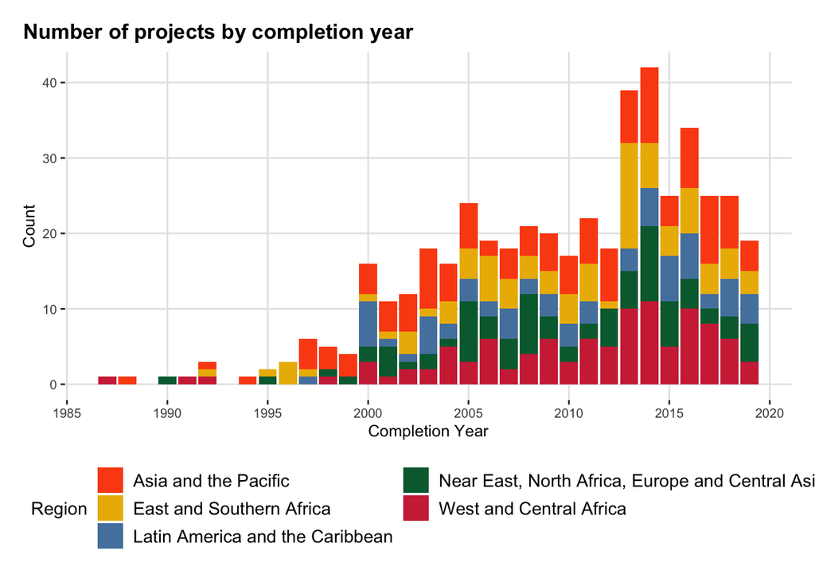

```r
p_number_projects_per_year <-
  pcr_lessons_learned %>%
  mutate(region = factor(Region,
                         levels = c("APR", "ESA", "LAC", "NEN", "WCA"),
                         labels = c("Asia and the Pacific",
                                    "East and Southern Africa",
                                    "Latin America and the Caribbean",
                                    "Near East, North Africa, Europe and Central Asia",
                                    "West and Central Africa"))) %>%
  ggplot(data = ., aes(x = year_current_completion)) +
  geom_bar(stat = "count", aes(fill = region)) +
  scale_fill_manual("Region", values = c("Asia and the Pacific" = "#FB4F14",
                                         "East and Southern Africa" = "#EBB700",
                                         "Latin America and the Caribbean" = "#5482AB",
                                         "Near East, North Africa, Europe and Central Asia" = "#00693C",
                                         "West and Central Africa" = "#CF2F44")) +
  scale_x_continuous(n.breaks = 10) +
  labs(x = "Completion Year", y = "Count", title = "Number of projects by completion year") +
  theme_mini() +
  guides(fill = guide_legend(nrow = 3))


p_number_projects_per_year
```

Let us now consider a choropleth map to show the number of projects per country. To that end, we can obtain a world map using the package {`rnaturalearth`}.

```r
library(sf)
library(rgeos)
library(rnaturalearth)
library(rnaturalearthdata)

world <- ne_countries(scale = "medium", returnclass = "sf")
```

Some adjustments on the names of countries need to be made, so that they match those of the world map from {`rnaturalearth`}.

```r
 map
```

[output not shown]

```r
pcr_lessons_learned <-
  pcr_lessons_learned %>%
  mutate(Country_map = Country) %>%
  mutate(Country_map = case_when(
    Country_map == "Viet Nam" ~ "Vietnam",
    Country_map == "Democratic People's Republic of Korea" ~ "South Korea",
    Country_map == "Lao People's Democratic Republic" ~ "Laos",
    Country_map == "Timor-Leste" ~ "East Timo",
    Country_map == "Eswatini" ~ "Swaziland",
    Country_map == "Bolivia (Plurinational State of)" ~ "Bolivia",
    Country_map == "Venezuela (Bolivarian Republic of)" ~ "Venezuela",
    Country_map == "Syrian Arab Republic" ~ "Syria",
    Country_map == "North Macedonia" ~ "Macedonia",
    Country_map == "Republic of Moldova" ~ "Moldova",
    Country_map == "Gambia (The)" ~ "Gambia",
    Country_map == "Côte d'Ivoire" ~ "Ivory Coast",
    Country_map == "Cabo Verde" ~ "Cape Verd",
    Country_map == "Congo" ~ "Republic of Congo",
    TRUE ~ Country_map
  ))
```

Let us store the number of projects per country in an object called `no_by_country_map`:

```r
no_by_country_map <-
  pcr_lessons_learned %>%
  group_by(Country_map) %>%
  count(name = "nb_obs") %>%
  arrange(desc(nb_obs)) %>%
  ungroup()
```

Lastly, we can create the choropleth map and plot it:

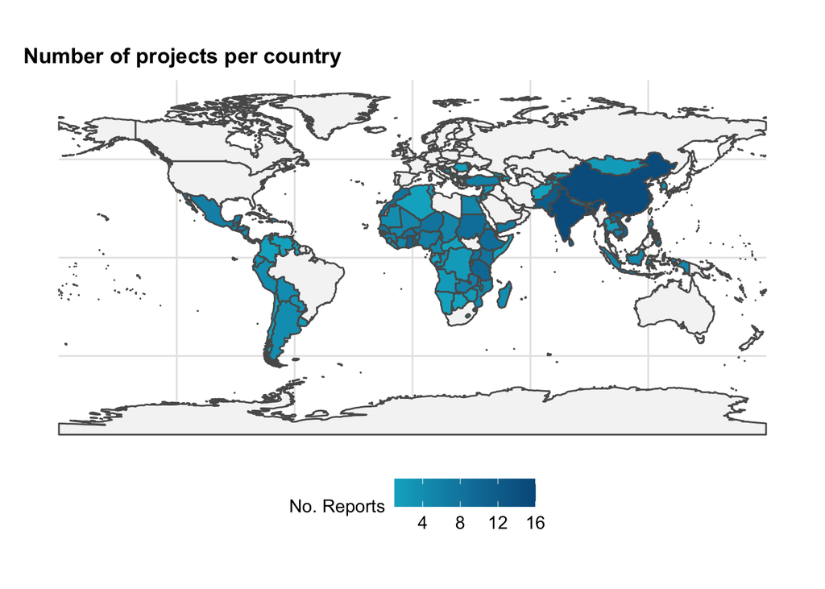

```r
p_map_number_projects_country <-
  ggplot(data = world %>%
         left_join(no_by_country_map,
                   by = c("admin" = "Country_map"))) +
  geom_sf(aes(fill = nb_obs)) +
  scale_fill_gradient("No. Reports",
                      low = "#00B0CA", high = "#005A8B",
                      na.value = "#F5F5F5") +
  labs(title = "Number of projects per country") +
  theme_mini()


p_map_number_projects_country
```

## 2.2 Lessons Learned

Let us turn to the lessons learned sections of the reports. First, we should remove the punctuation characters from the text and convert all words to lower case:

```r
pcr_lessons_learned <-
  pcr_lessons_learned %>%
  mutate(lessons_learned_clean =
           lessons_learned %>%
           str_remove_all("[[:punct:]]") %>%
           str_remove_all("[[:digit:]]") %>%
           str_remove_all("\n") %>%
           str_trim() %>%
           str_remove_all("[[:space:]]{2,}") %>%
           str_to_lower())
```

Let us count how many characters and how many words are in the section “Lessons Learned” of each report:

```r
pcr_lessons_learned <-
  pcr_lessons_learned %>%
  mutate(no_chars = str_length(lessons_learned_clean),
         no_words = str_count(lessons_learned_clean, "\\S+"))
```

```r
library(scales)
```

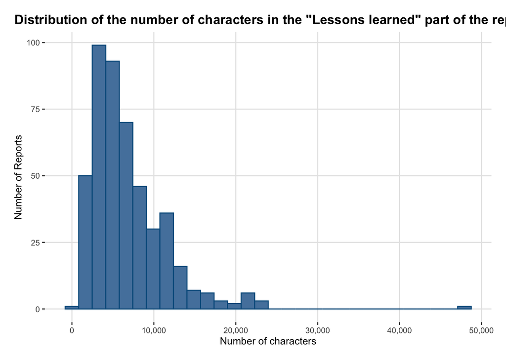

```r
p_no_characters <-
  ggplot(data = pcr_lessons_learned) +
  geom_histogram(aes(x = no_chars), fill = "#5482AB", colour = "#005A8B") +
  theme_mini() +
  labs(title = "Distribution of the number of characters in the \"Lessons learned\" part of the reports",
       y = "Number of Reports", x = "Number of characters") +
  scale_x_continuous(label=comma)
p_no_characters
```

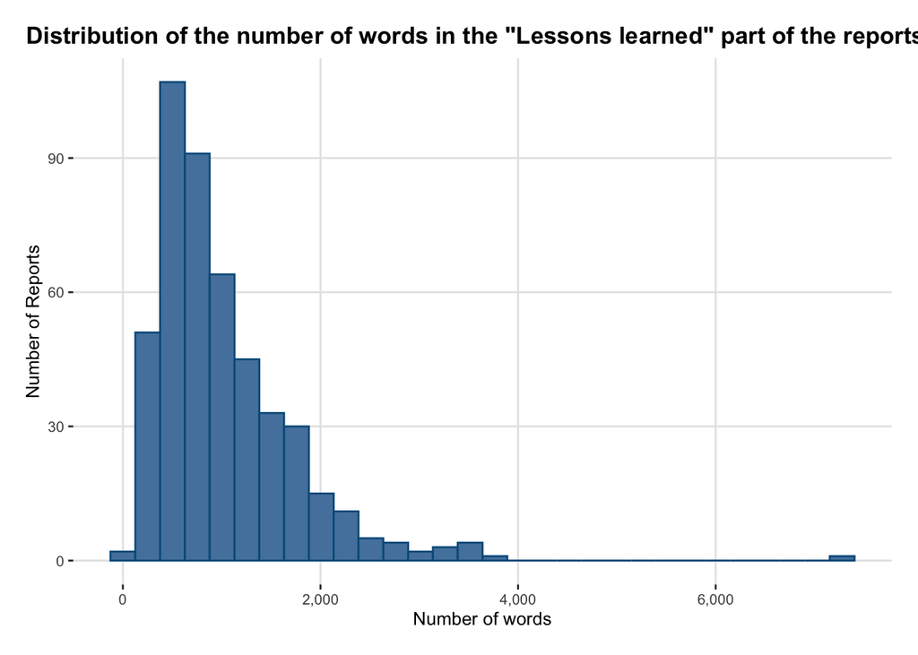

```r
p_no_words <-
  ggplot(data = pcr_lessons_learned) +
  geom_histogram(aes(x = no_words), fill = "#5482AB", colour = "#005A8B") +
  theme_mini() +
  labs(title = "Distribution of the number of words in the \"Lessons learned\" part of the reports",
       y = "Number of Reports", x = "Number of words") +
  scale_x_continuous(label=comma)
p_no_words
```

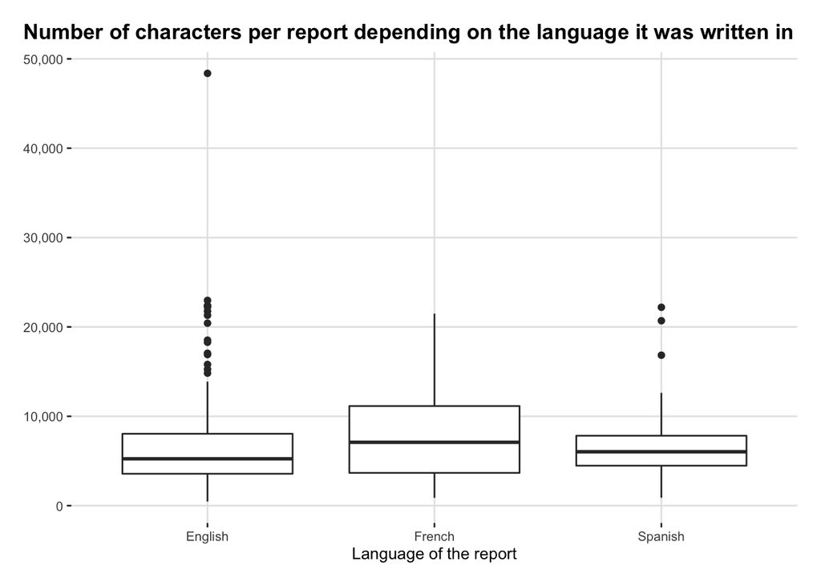

```r
p_boxplot_no_characters <-
  ggplot(data = pcr_lessons_learned) +
  geom_boxplot(aes(x = language_report, no_chars)) +
  theme_mini() +
  labs(x = "Language of the report", y = NULL,
       title = "Number of characters per report depending on the language it was written in") +
  scale_y_continuous(label=comma)

p_boxplot_no_characters
```

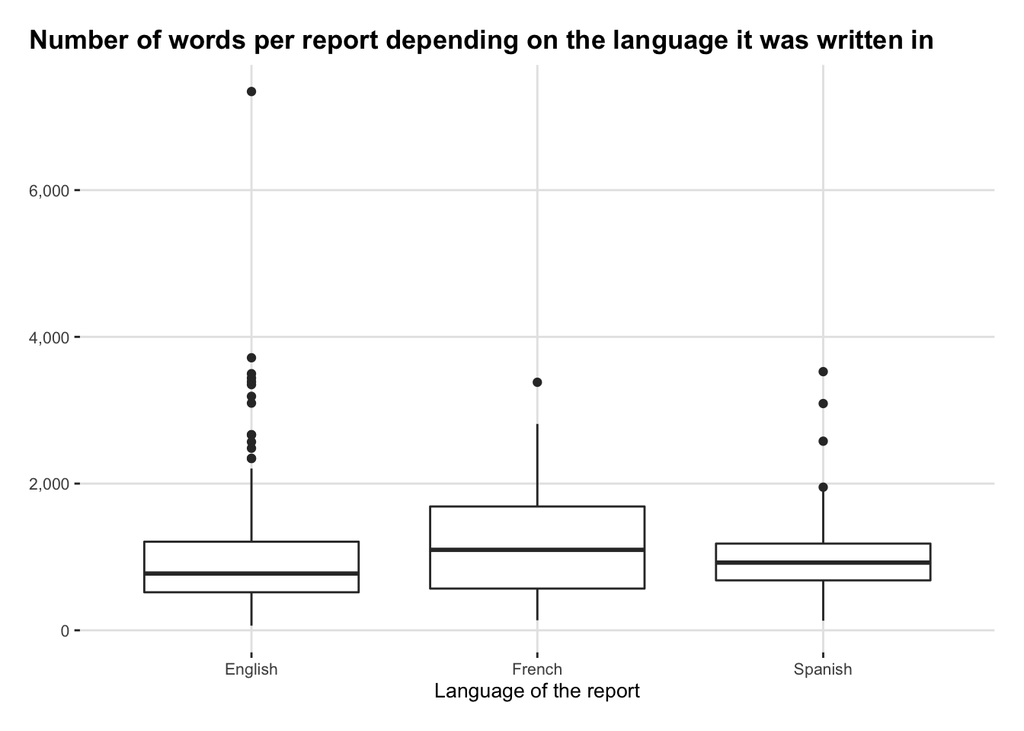

```r
p_boxplot_no_words <-
  ggplot(data = pcr_lessons_learned) +
  geom_boxplot(aes(x = language_report, no_words)) +
  theme_mini() +
  labs(x = "Language of the report", y = NULL,
       title = "Number of words per report depending on the language it was written in") +
  scale_y_continuous(labels = comma)
p_boxplot_no_words
```